# Mutual Funds

### This is the subset and summary of the Mutual Fund data set used

```r
source("../02 Data Wrangling/SQL To R.R", echo = FALSE)
head(GF)
```

```
##   ICDI      DATE_             TNAM                RETM             NAVM
## 1   64 11/28/2003 35.2000007629395 0.00148754194378853 26.9300003051758
## 2   64 12/31/2003               36  0.0656971707940102 24.7299995422363
## 3   64  1/30/2004 36.0999984741211  0.0266882330179214 25.3899993896484
## 4   64  2/27/2004 34.7999992370605 0.00866482872515917 25.6100006103516
## 5   64  3/31/2004 34.5999984741211 -0.0167903155088425 25.1800003051758
## 6   64  4/30/2004 35.2999992370605  -0.012708499096334 24.8600006103516
##   YEAR MONTH
## 1 2003    11
## 2 2003    12
## 3 2004     1
## 4 2004     2
## 5 2004     3
## 6 2004     4
```

```r
summary(GF)
```

```
##       ICDI             DATE_                        TNAM
##  Min.   :  51   3/29/1996 :  263   null               : 1165
##  1st Qu.: 838   4/30/1996 :  262   0.100000001490116  :   96
##  Median :1754   5/31/1996 :  261   0.200000002980232  :   90
##  Mean   :1708   6/28/1996 :  260   0.00100000004749745:   70
##  3rd Qu.:2587   12/29/1995:  259   1.29999995231628   :   62
##  Max.   :3316   2/29/1996 :  259   1.39999997615814   :   62
##                 (Other)   :27807   (Other)            :27826
##                   RETM                     NAVM            YEAR
##  null               :  507   null            :  260   Min.   :1992
##  0                  :  230   9.97000026702881:   48   1st Qu.:1996
##  0.0399999991059303 :   11   10              :   44   Median :1999
##  -0.0384615361690521:   10   11.1199998855591:   40   Mean   :1999
##  0.0217391308397055 :   10   10.8599996566772:   37   3rd Qu.:2002
##  0.0526315793395042 :   10   10.6700000762939:   36   Max.   :2007
##  (Other)            :28593   (Other)         :28906
##      MONTH
##  Min.   : 1.000
##  1st Qu.: 3.000
##  Median : 6.000
##  Mean   : 6.492
##  3rd Qu.:10.000
##  Max.   :12.000
##
```

### This is the subset and summary of the Market data set used

```r
source("../02 Data Wrangling/SQL To R.R", echo = FALSE)
head(FF)
```

```
##      DATE_  MKT_RF   SMB  HML     RF YEAR MONTH
## 1 1/1/1992 -0.0046  8.43 4.53 0.0034 1992     1
## 2 2/1/1992  0.0106  0.88 6.37 0.0028 1992     2
## 3 3/1/1992 -0.0271 -1.04 3.66 0.0034 1992     3
## 4 4/1/1992  0.0102 -6.11 4.33 0.0032 1992     4
## 5 5/1/1992  0.0036  0.40 1.23 0.0028 1992     5
## 6 6/1/1992 -0.0225 -3.09 3.30 0.0032 1992     6
```

```r
summary(FF)
```

```
##       DATE_         MKT_RF              SMB                HML
##  1/1/1992:  1   Min.   :-0.06410   Min.   :-16.7000   Min.   :-12.800
##  1/1/1993:  1   1st Qu.:-0.01350   1st Qu.: -2.0350   1st Qu.: -1.365
##  1/1/1994:  1   Median : 0.01045   Median : -0.3150   Median :  0.315
##  1/1/1995:  1   Mean   : 0.01022   Mean   :  0.0373   Mean   :  0.388
##  1/1/1996:  1   3rd Qu.: 0.03352   3rd Qu.:  2.0150   3rd Qu.:  2.075
##  1/1/1997:  1   Max.   : 0.07220   Max.   : 22.1800   Max.   :  9.080
##  (Other) :116
##        RF                YEAR          MONTH
##  Min.   :0.002100   Min.   :1992   Min.   : 1.000
##  1st Qu.:0.003100   1st Qu.:1994   1st Qu.: 3.000
##  Median :0.003900   Median :1997   Median : 6.000
##  Mean   :0.003707   Mean   :1998   Mean   : 6.352
##  3rd Qu.:0.004300   3rd Qu.:2000   3rd Qu.: 9.000
##  Max.   :0.005600   Max.   :2007   Max.   :12.000
##
```

#### This is the first plot

```
##
## > require("jsonlite")
##
## > require("RCurl")
##
## > require(dplyr)
##
## > require(lubridate)
##
## > require(ggplot2)
##
## > FF <- data.frame(fromJSON(getURL(URLencode("129.152.144.84:5001/rest/native/?query=\"select * from FAMA_FRENCH\""),
## +     httpheader = c(DB = "jdbc ..." ... [TRUNCATED]
##
## > GF <- data.frame(fromJSON(getURL(URLencode("129.152.144.84:5001/rest/native/?query=\"select * from GROWTH_FUND\""),
## +     httpheader = c(DB = "jdbc ..." ... [TRUNCATED]
##
## > GF <- GF %>% mutate(YEAR = year(parse_date_time(DATE_,
## +     "%m%d%y")))
##
## > GF <- GF %>% mutate(MONTH = month(parse_date_time(DATE_,
## +     "%m%d%y")))
##
## > FF <- FF %>% mutate(RF = RF/100)
##
## > FF <- FF %>% mutate(MKT_RF = MKT_RF/100)
##
## > InJoin <- dplyr::inner_join(GF, FF, by = c("YEAR",
## +     "MONTH"))
##
## > retm <- as.numeric(as.character(unlist(InJoin[4])))
```

```
##
## > InJoin <- InJoin %>% mutate(retm_rf = retm - RF)
##
## > InJoin <- InJoin %>% mutate(retm_mkt = retm - MKT_RF)
##
## > InJoin %>% group_by(ICDI) %>% filter(retm_mkt <= 2) %>%
## +     summarise(avg = mean(retm_mkt)) %>% ggplot(aes(x = ICDI,
## +     y = avg)) + geom_poin .... [TRUNCATED]
```

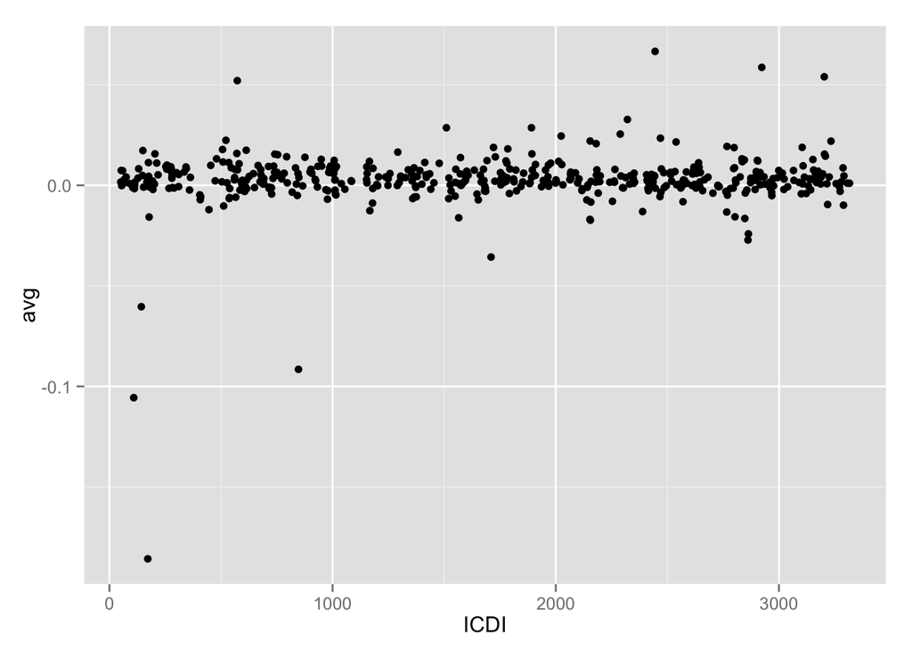

```r
source("../03 Visualizations/Plot 1.R", echo = TRUE)
```

#### This is the second plot

```
##
## > require("jsonlite")
##
## > require("RCurl")
##
## > require(dplyr)
##
## > require(lubridate)
##
## > require(ggplot2)
##
## > require(graphics)
##
## > FF <- data.frame(fromJSON(getURL(URLencode("129.152.144.84:5001/rest/native/?query=\"select * from FAMA_FRENCH\""),
## +     httpheader = c(DB = "jdbc ..." ... [TRUNCATED]
##
## > GF <- data.frame(fromJSON(getURL(URLencode("129.152.144.84:5001/rest/native/?query=\"select * from GROWTH_FUND\""),
## +     httpheader = c(DB = "jdbc ..." ... [TRUNCATED]
##
## > GF <- GF %>% mutate(YEAR = year(parse_date_time(DATE_,
## +     "%m%d%y")))
##
## > GF <- GF %>% mutate(MONTH = month(parse_date_time(DATE_,
## +     "%m%d%y")))
##
## > FF <- FF %>% mutate(RF = RF/100)
##
## > FF <- FF %>% mutate(MKT_RF = MKT_RF/100)
##
## > OuterJ <- dplyr::right_join(GF, FF, by = c("YEAR",
## +     "MONTH"))
##
## > retm <- as.numeric(as.character(unlist(OuterJ[4])))
```

```
##
## > OuterJ <- OuterJ %>% mutate(retm_rf = retm - RF)
##
## > OuterJ <- OuterJ %>% mutate(retm_mkt = retm - MKT_RF)
##
## > df <- OuterJ %>% filter(ICDI == 51)
##
## > fit <- lm(retm_rf ~ MKT_RF, data = df)
##
## > summary(fit)
##
## Call:
## lm(formula = retm_rf ~ MKT_RF, data = df)
##
## Residuals:
##       Min        1Q    Median        3Q       Max
## -0.126303 -0.014051 -0.004796  0.015641  0.079579
##
## Coefficients:
##             Estimate Std. Error t value Pr(>|t|)
## (Intercept) 0.002261   0.003620   0.625    0.534
## MKT_RF      0.649654   0.097260   6.680  3.5e-09 ***
## ---
## Signif. codes:  0 '***' 0.001 '**' 0.01 '*' 0.05 '.' 0.1 ' ' 1
##
## Residual standard error: 0.02985 on 76 degrees of freedom
##   (1 observation deleted due to missingness)
## Multiple R-squared:  0.3699, Adjusted R-squared:  0.3616
## F-statistic: 44.62 on 1 and 76 DF,  p-value: 3.504e-09
##
##
## > OuterJ %>% filter(ICDI == 51) %>% ggplot(aes(x = MKT_RF,
## +     y = retm_rf)) + geom_point() + stat_smooth(method = "lm",
## +     col = "red")
```

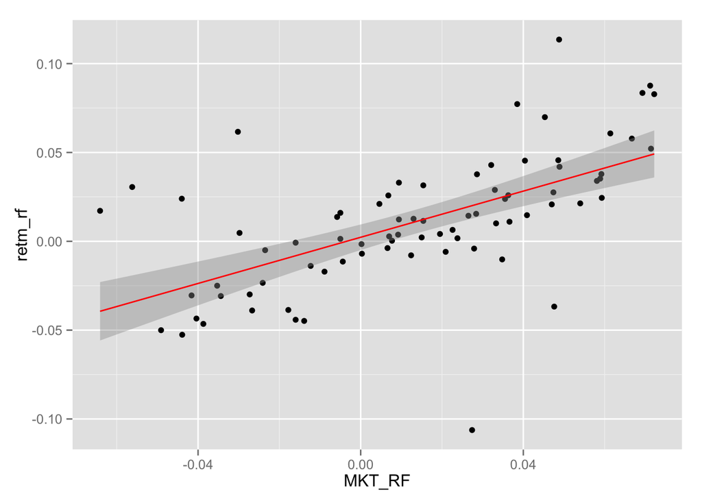

```r
source("../03 Visualizations/Plot 2.R", echo = TRUE)
```

Plot 2: The beta of the fund (outer join) In this plot, we used a regression to find the correlation between the market premium (return on market - risk free rate) and the fund return premium (return on fund - risk free rate). The coefficient we found suggested a positive beta. Whether any of the funds have positive alpha would need furthur investigation.